# 內容農場的秘密讓全台灣都驚呆了!

## 濫用標點符號分析

驚嘆號「!」是每個農場下標時的必備元素，刪節號「…」則為EBCbuzz(躁咖)之外的三個農場所用。

「瑞典的資源回收『台灣必須現在立馬跟進』，神到不可置信的效率連垃圾都已經缺貨了！」  
「妻子在臨睡前暗示著丈夫『她想要離婚』，沒想到丈夫意料之外的回答讓她哭了一整夜…」  
「這個學生『故意讓小偷拿走手機』，接著他就展開了追蹤整個後續的記錄片…！」

## 不同詞性的高頻詞分析

1. Bomb01
2. teepr
3. ptt01

4.EBCbuzz

[figure not shown]

[figure not shown]

## 不同詞性的高頻詞分析-名詞

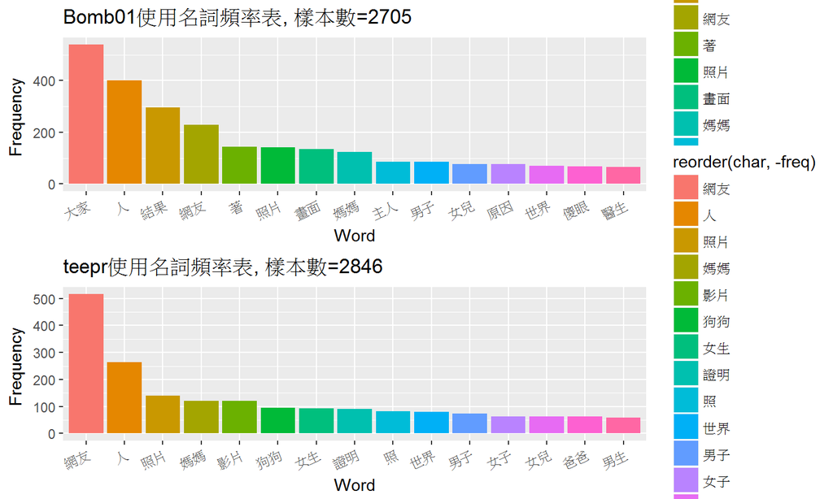

```r
multiplot(Bomb01_n, teepr_n, cols=1)
```

## 不同詞性的高頻詞分析-名詞

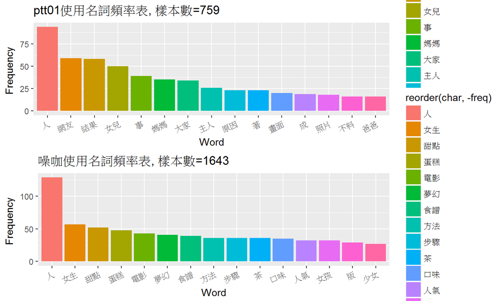

```r
multiplot(ptt01_n, EBCbuzz_n, cols=1)
```

## 不同詞性的高頻詞分析-名詞

「大家」、「網友」、「人」為幾個常見用字，有製造輿論的效果。

- 「 大家一開始看到這團棉花時還想說是誰弄掉了，結果看到棉花球「一抬起頭」時才發現是地表最萌驚喜！」
- 「她問退伍的爺爺「中校12級退役大嗎？」， 網友都跪了…」

## 不同詞性的高頻詞分析-動詞

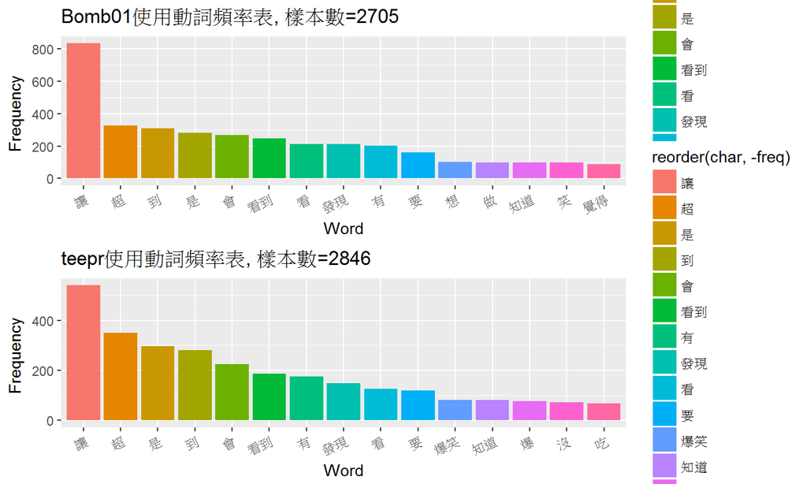

```r
multiplot(Bomb01_v, teepr_v, cols=1)
```

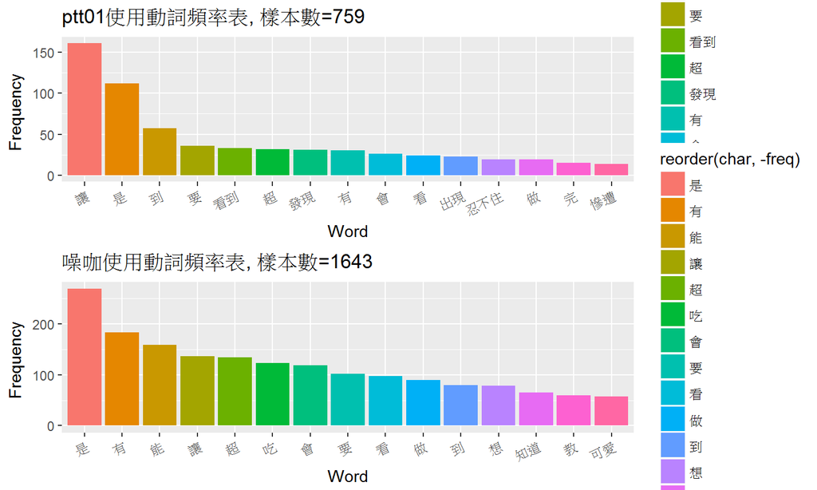

```r
multiplot(ptt01_v, EBCbuzz_v, cols=1)
```

## 不同詞性的高頻詞分析-動詞

「讓」榮登農場最愛用動詞。

- 「他在17歲「變性成女生」後竟淪落到賣淫自殘，1年後決定「重返男兒身」的他 讓大家都看傻了！」

## 不同詞性的高頻詞分析-形容詞

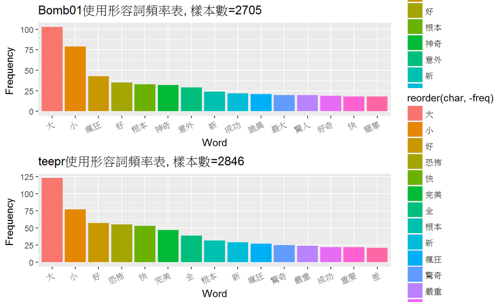

```r
multiplot(Bomb01_a, teepr_a, cols=1)
```

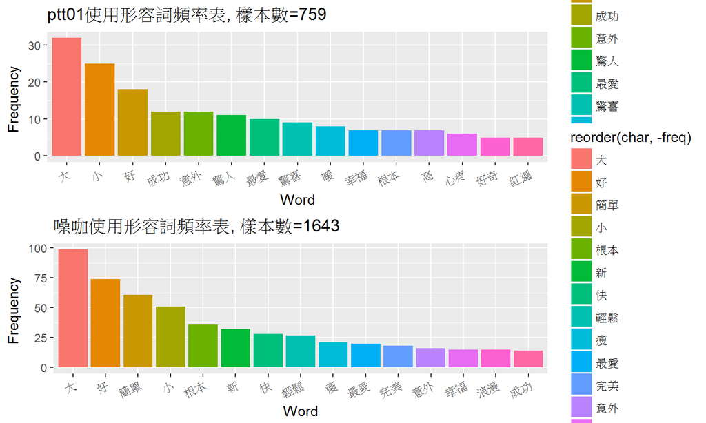

```r
multiplot(ptt01_a, EBCbuzz_a, cols=1)
```

## 不同詞性的高頻詞分析-形容詞

「大」強調程度不一般，可以強化渲染力。

- 「艾迪瑞德曼「比電影還精彩」真實背景 大揭密！貴族家庭出身的他說「很對不起威廉王子…」」

## 不同詞性的高頻詞分析-副詞

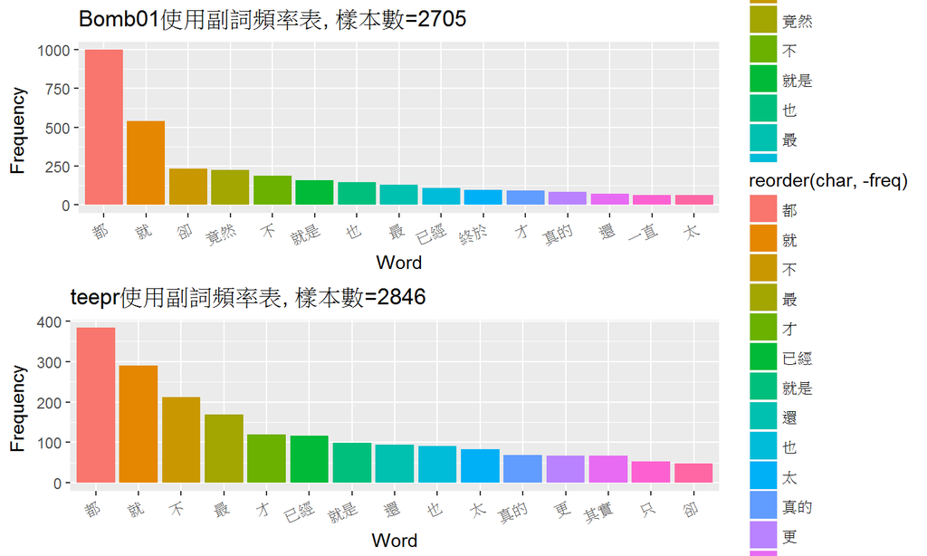

```r
multiplot(Bomb01_d, teepr_d, cols=1)
```

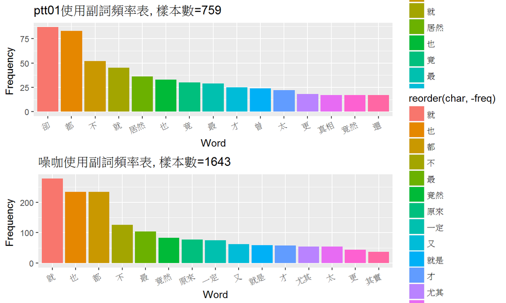

```r
multiplot(ptt01_d, EBCbuzz_d, cols=1)
```

## 不同詞性的高頻詞分析-副詞

大量使用「都」字，營造「大家一致認可」的感覺。

- 「她騎著哈雷機車跟男友單膝下跪求婚，說完會加碼送房產後「一轉頭」…大家 都發出哇一聲！」

## 高迴響與低迴響文

1. 高迴響文：該分享所得讚數之z分數其粉絲團中高於1。
2. 低迴響文：該分享所得讚數之z分數其粉絲團中低於0。

## 建立詞性頻率表

1. Bomb01高迴響文
2. Bomb01低迴響文
3. teepr高迴響文
4. teepr低迴響文
5. ptt01高
6. ptt01低
7. EBC高
8. EBC低

## 用詞分析-名詞

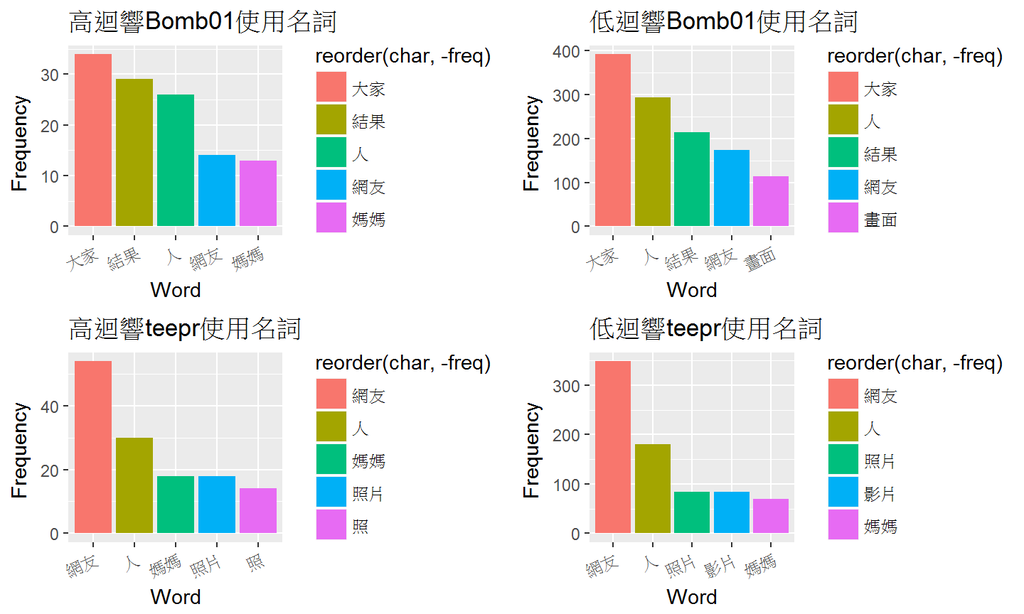

```r
multiplot(bomb_h_n, teepr_h_n, bomb_l_n, teepr_l_n,  cols=2)
```

## 用詞分析-名詞

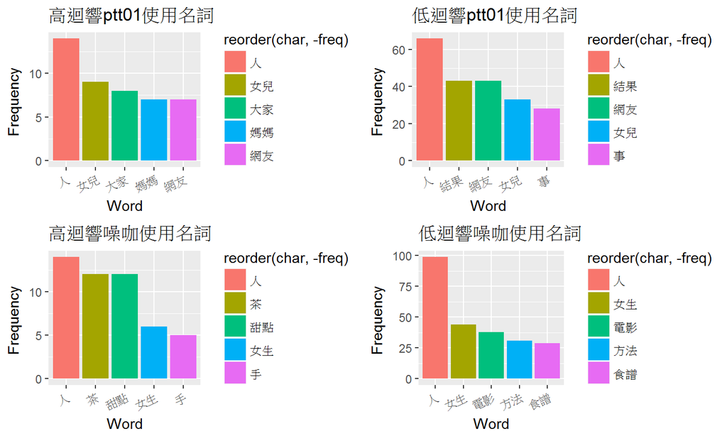

```r
multiplot(ptt01_h_n, EBC_h_n, ptt01_l_n, EBC_l_n, cols=2)
```

## 不同時間貼文的讚數分析

1. Bomb01
2. teepr
3. ptt01
4. EBCbuzz

## 不同時間貼文的讚數分析

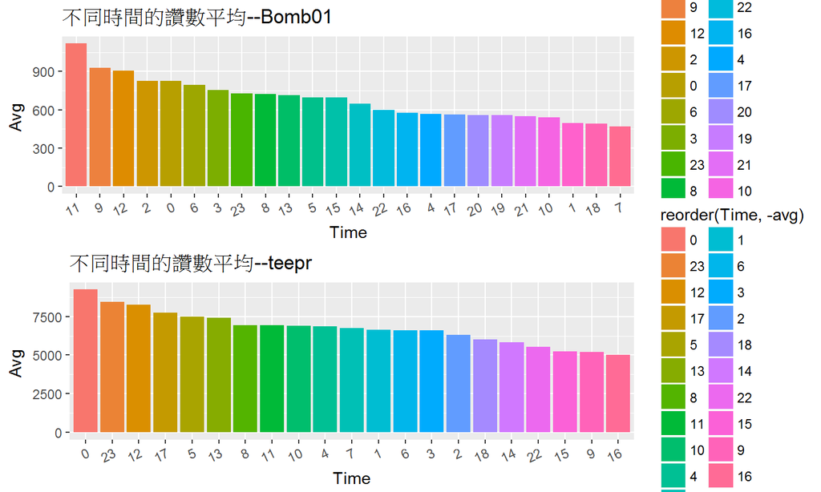

```r
multiplot(time_bomb_graph, time_teepr_graph, cols=1)
```

## 不同時間貼文的讚數分析

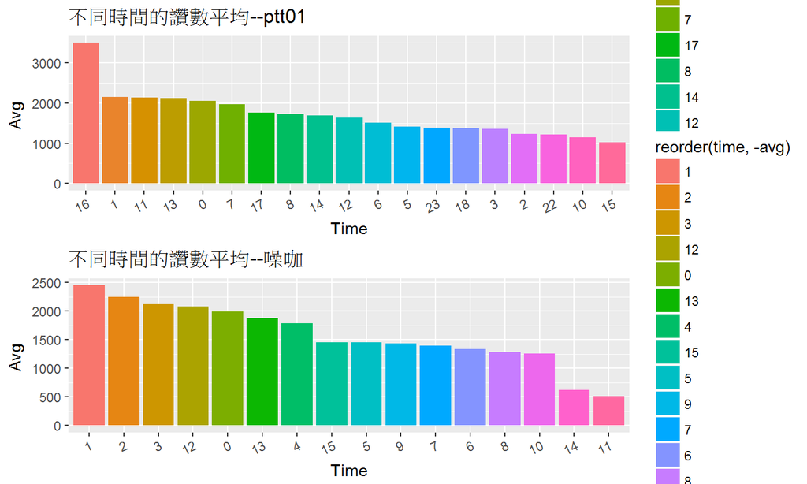

```r
multiplot(time_ptt_graph, time_EBC_graph, cols=1)
```

## 標題長度與所得讚數的關聯

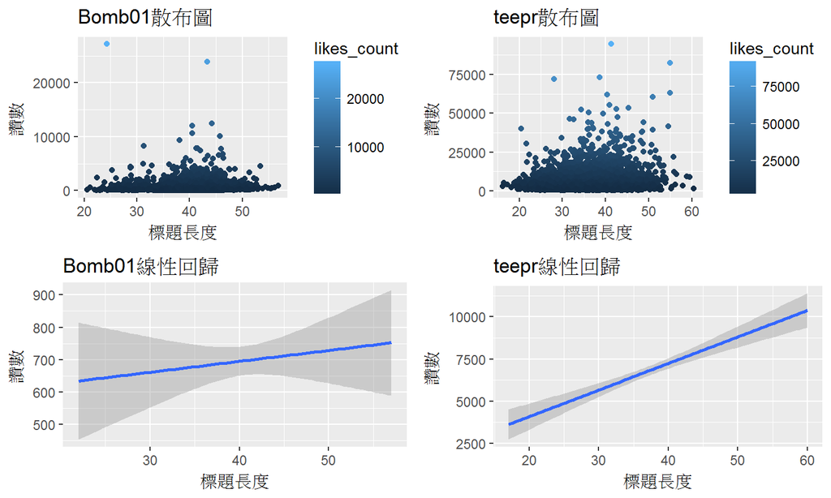

```r
multiplot(distribution1, lm1, distribution2, lm2, cols=2)
```